# ex_11

Nikolai German

2025-07-20

# Ex 1: Distributions

## a)

### i) Geometric Distribution

#### 2)

We take the Geometric Distribution quite literally, and just “flip” coins until we get a success, while counting, how many times we’ve been unsuccesfull.

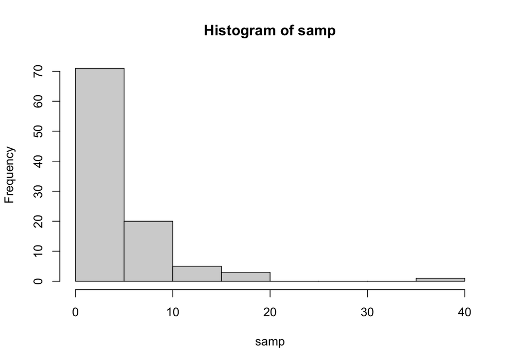

```r
rgeom_custom <- function(n = 1, p = .5) {
  inner <- function() {
    x <- 0
    repeat {
      u <- runif(1)
      if (u < p) {
        break
      } else {
      x <- x + 1
      }
    }
  return(x)
  }
  replicate(n, inner())
}

samp <- rgeom_custom(100, .2)
hist(samp)
```

### ii) Cauchy Distribution

#### 2)

We use somewhat a reverse Box-Muller approach. We know that if we sample $r \in [0,1]$ and $\theta \in [0, 2\pi]$, we obtain points within the unit circle $(r \cos(\theta), r \sin(\theta))$. Thus $X/Y$ simplifies to $\frac{r \cos(\theta)}{r \sin(\theta)} = \frac{1}{\tan(\theta)}$

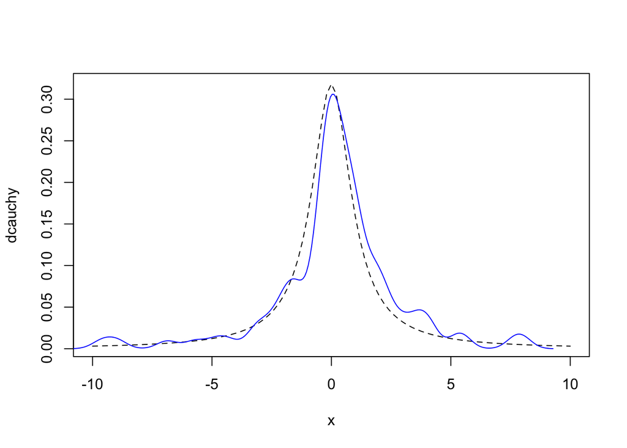

```r
set.seed(121)
samp <- 1/tan(2*pi*runif(100))
dens <- density(samp)

plot(dcauchy, xlim = c(-10,10), lty = "dashed")
lines(dens$x, dens$y, col = "blue")
```

### iii) Poisson Distribution

We simply sample independently from the exponential distribution until the cumulative sum is greater than 1. The number of samples, which did not cause to overflow is possion distributed.

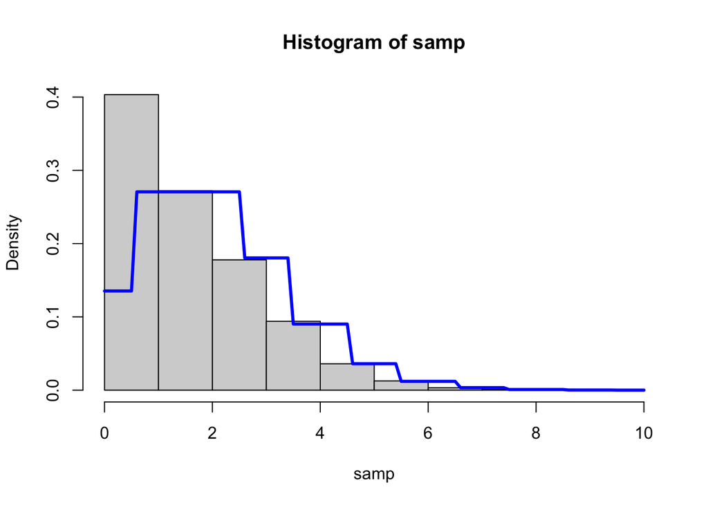

```r
rpois_custom <- function(n, lambda = 1) {
  inner <- function() {
    t <- 0
    x <- 0
    while (t < 1) {
      t <- t - log(runif(1)) / lambda # Inversion for EXP
      if (t < 1) {
        x <- x + 1
      }
    }
    return(x)
  }
  replicate(n, inner())
}

samp <- rpois_custom(10000, 2)

hist(samp, freq = FALSE, breaks = 10)
plot(function(x) dpois(round(x), 2), add = TRUE, col = "blue", lwd = 3, xlim = c(0, 10))
```

## b)

The sum of two squared standard normal rvs is a chi-squared rv with $df=2$. For the CDF of a $\mathcal{X}^2$ rv, the following holds:

$$F(x) = 1 - \exp(-\frac{x}{2})$$

Therefore the inverse of this CDF can be computed as:

$$\begin{align*}
u &= 1 - \exp(-\frac{x}{2}) \\
-\frac{x}{2} &= \log(1 - u) \\
x &= -2 \cdot log(1 - u)
\end{align*}$$

Since $u \sim \text{Unif}(0,1) \implies 1-u \sim \text{Unif}(0,1)$, we can write $Q(U) = -2 \cdot log(U)$

Next we want to find a way to decompose a $\mathcal{X}^2_2$ rv into two standard normals:

We could simply use a uniform auxilary variable to compute the fraction of $X^2$ and $Y^2$, the use the square root. This has a major limitation, that it will only return positve values. To overcome this, we would need to sample again in order to generate the sign, which would leave us with four uniform samples to generate two standard normals:

```r
fourtotwo <- function() {
  chi <- -2*log(runif(1))
  frac <- runif(1)
  X_sq <- frac * chi
  Y_sq <- (1-frac) * chi
  X <- ifelse(runif(1) > .5, 1, -1) * sqrt(X_sq)
  Y <- ifelse(runif(1) > .5, 1, -1) * sqrt(Y_sq)
  return(c(X, Y))
}
```

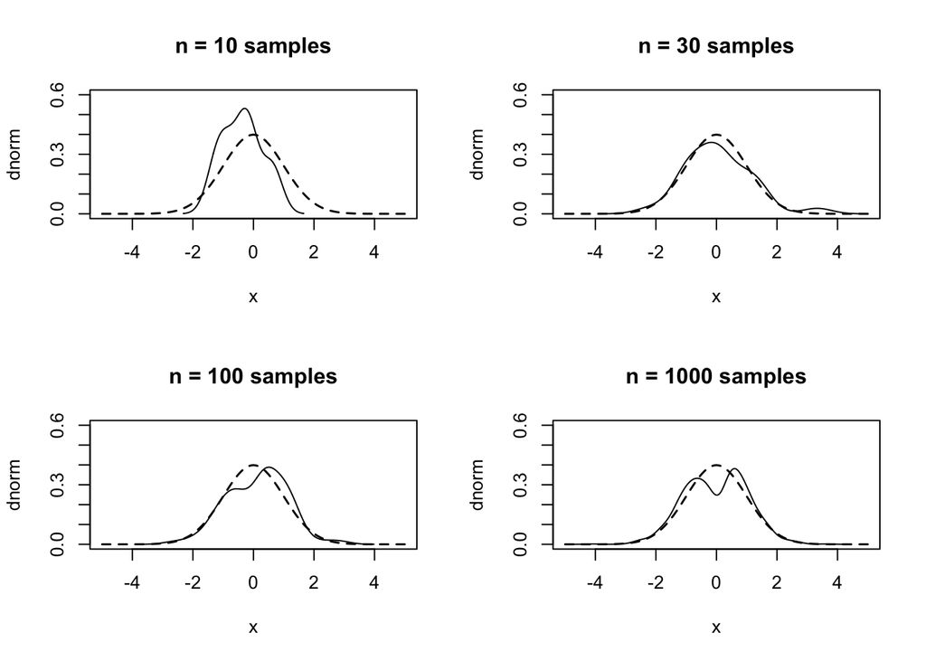

This shows promising results in the tails, yet around the expectation, the density of samples do not follow a standard normal.

Another decompostion could be the folowing: We know that $\sin^2(\theta) + \cos^2(\theta) = 1$. We multiply both sides by $r \sim \mathcal{X}^2_2$, which we obtained by inversion: $r \sin^2(\theta) + r \cos^2(\theta) = r$. Then we can identify $X^2 = r \sin^2(\theta)$ and $Y^2 = r \cos^2(\theta)$, which leads us to $X = \sqrt{r} \sin(\theta)$ and $Y = \sqrt{r} \cos(\theta)$.

```r
box.muller <- function() {
  r <- sqrt(-2*log(runif(1)))
  theta <- 2*pi*runif(1)
  X <- r * cos(theta)
  Y <- r * sin(theta)
  return(c(X, Y))
}
```

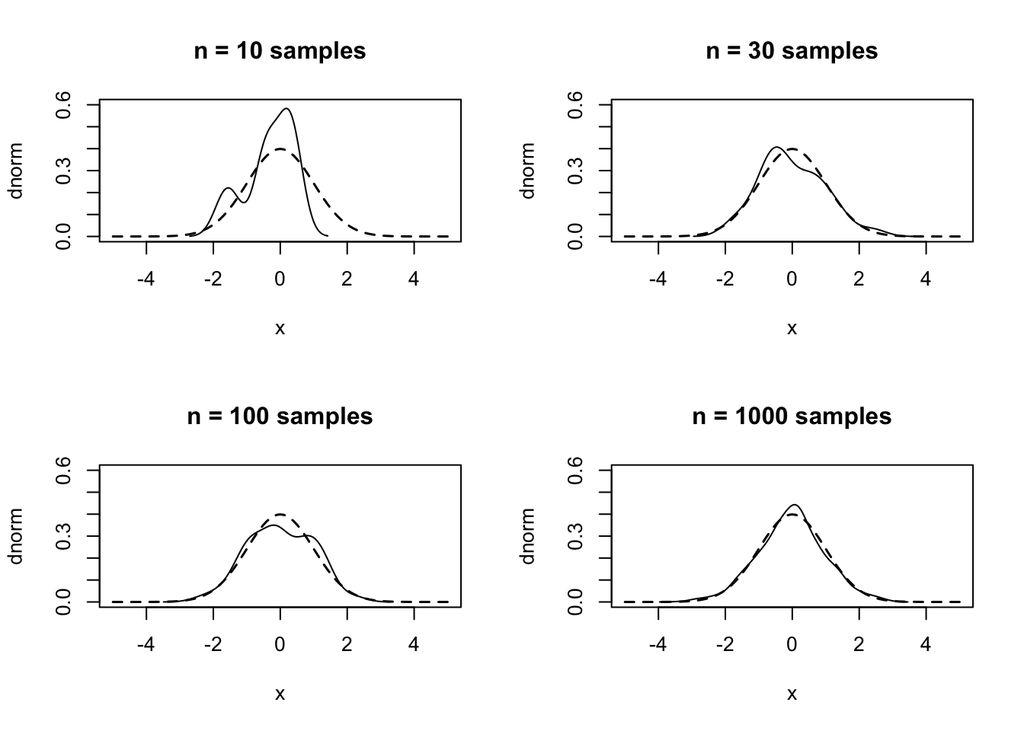